# Visualization 02 - ggplot loves tidy data - Completed Version

Yujie Su, M.S. & Matthew Schuelke, Ph.D.

(September 17, 2019)

## Introduction

In this lesson, we will explore how the structure of data influences visualizations, and how to transform data into a tidy format.

## Load Dependencies

The following code loads the package dependencies for our analysis:

```r
library(dplyr)    # data wrangling
library(tidyr)    # data wrangling
library(ggplot2)  # data plotting
library(readr)    # work with csv files
```

Now you try loading two additional packages - `here` (for working with file paths) and `skimr` (for generating descriptive statistics):

```r
library(here)
library(skimr)
```

We now have the packages needed for our analyses.

## Load Data

```r
house_1 <- read_csv(here('data', 'house_1.csv'))
```

Now you try to load data ‘house_2.csv’

```r
house_2 <- read_csv(here('data', 'house_2.csv'))
```

## Objects and Layers

In this section, we will explore how the structure of data influences visualizations. Before plotting, we need to understand our data a little bit.

### Data Layer

To understand how the data structure relates to plotting, let’s look at the `house_1` data set.

```r
print(house_1)
```

| Id | Year | Ages | Style | LotArea | GrLivArea | SalePrice |
| --- | --- | --- | --- | --- | --- | --- |
| 1 | 2004 | Young | OneStory | 3182 | 1269 | 192000 |
| 2 | 1998 | Young | OneStory | 10140 | 1680 | 213250 |
| 3 | 1950 | Old | OneStory | 9600 | 1067 | 128000 |
| 4 | 1992 | Young | TwoStory | 10186 | 1923 | 190000 |
| 5 | 2006 | Young | TwoStory | 15611 | 1919 | 233230 |
| 6 | 2005 | Young | OneStory | 6955 | 1368 | 202500 |
| 7 | 1955 | Old | Other | 9600 | 1661 | 165500 |
| 8 | 1977 | Young | TwoStory | 12227 | 2872 | 272000 |
| 9 | 1949 | Old | TwoStory | 6270 | 2002 | 145000 |
| 10 | 2009 | Young | TwoStory | 3951 | 1224 | 164500 |

[output cut: 180 more lines]

For the data set, each column is a variable, and we have 7 variables in the `house_1` data set.

*I will show you the difference between quick base plots and quick ggplot plots first.*

## Base plot

We could call the `base` package `plot` function by positional arraying the x and y variables as the `plot()` function arguments to make a scatter plot of `SalePrice` against `GrlivArea`.

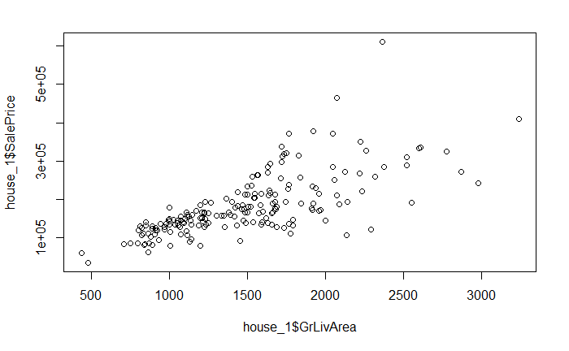

```r
plot(house_1$GrLivArea, house_1$SalePrice)
```

If we want to add a fit line describing the relationship between `GrLivArea` and `SalePrice` we can use `lines()` in conjunction with `lowess()` and color it blue.

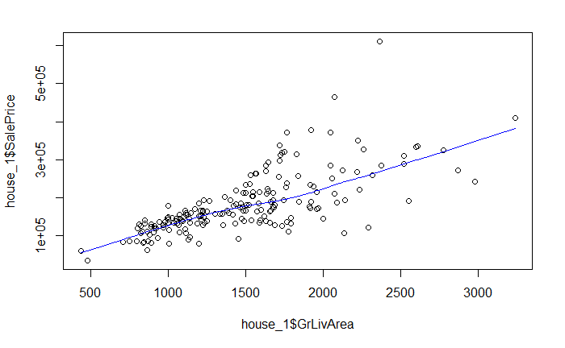

```r
plot(house_1$GrLivArea, house_1$SalePrice)
lines(lowess(house_1$GrLivArea, house_1$SalePrice), col = "blue")
```

Limitations of base plot:

1. Plot doesn’t get redrawn.
2. Plot is drawn as an image, and we keep adding on that image.
3. Need to manually add legend.
4. No unified framework for plotting.

## ggplot2

The central function in `ggplot2` is `ggplot()`. You will use it on all variety of plots we make.

What we have here are two layers of `ggplot2`: data and aesthetics. Data is our data set, `house_1`, and we will use the same aesthetics that we used in base plot, Y is `SalePrice` plotted against X, `GrlivArea`.

To specify the `geom_point` layer, we can add a plus at the end of first argument, then add a `geom_point()` function. No argument is needed right now.

This is same as the first plot we created with base package.

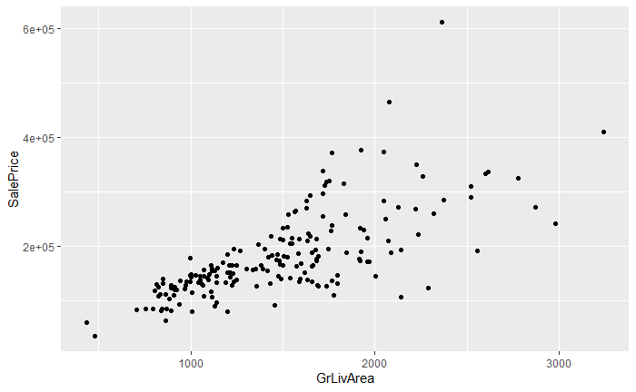

```r
ggplot(house_1, aes(x = GrLivArea, y = SalePrice)) +
  geom_point()
```

### ggplot object

A major difference between `ggplot` and base plot is that `ggplot` creates an object that can be saved and manipulated.

We could assign the basic layers to an object called `p`, for example. We can recycle the object with a variety of different plot types.

First we make the common, underlying object.

```r
p <- ggplot(house_1, aes(x = GrLivArea, y = SalePrice))
```

Then we can add layer to that object such as `geom_points()`.

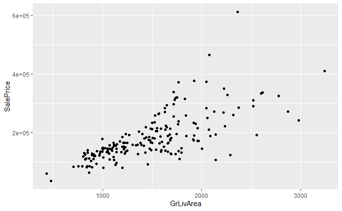

```r
p + geom_point()
```

Or we could instead add a `geom_smooth()`.

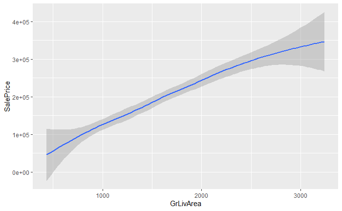

```r
p + geom_smooth()
```

We can assign multiple layers for an object, and then when I call p, the data, the aesthetic and the geom which define the plot type is drawn.

```r
p <- ggplot(houseWide, aes(x = GrLivArea, y = SalePrice)) +
  geom_point() +
  geom_smooth()

p
```

[output not shown]

By now you should see that ggplot is a very flexible way of making complex plots.

Now it’s your turn to make a plot.

First print out the contents of `house_2` to see its structure.

```r
print(house_2)
```

| Id | SalePrice | Foundation | RoofStyle | FFlrSF | SFlrSF | TotalBsmtSF | YearBuilt | Ages |
| --- | --- | --- | --- | --- | --- | --- | --- | --- |
| 1 | 160000 | BrkTil | Gable | 976 | 332 | 728 | 1940 | Old |
| 2 | 215000 | PConc | Gable | 1065 | 846 | 777 | 1993 | Young |
| 3 | 81000 | PConc | Gambrel | 658 | 526 | 658 | 1910 | Old |
| 4 | 197000 | CBlock | Hip | 1040 | 685 | 539 | 1979 | Young |
| 5 | 176000 | CBlock | Gable | 1098 | 880 | 832 | 1968 | Old |
| 6 | 225000 | CBlock | Gable | 1122 | 1121 | 700 | 1990 | Young |
| 7 | 148500 | CBlock | Gable | 855 | 601 | 855 | 1976 | Old |
| 8 | 148500 | CBlock | Gable | 855 | 586 | 855 | 1978 | Young |
| 9 | 200000 | CBlock | Gable | 1338 | 1296 | 1248 | 1969 | Old |
| 10 | 189950 | BrkTil | Gable | 912 | 514 | 912 | 1918 | Old |

[output cut: 190 more lines]

Then make a scatter plot of `SalePrice` against first floor square feet (`FFlrSF`), and add a fitted loess line on it.

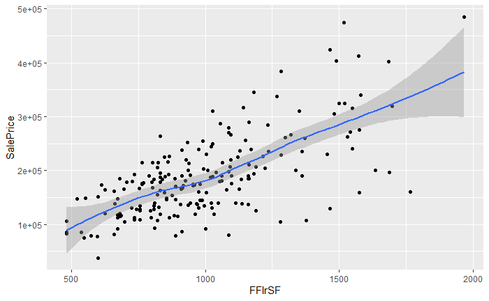

```r
ggplot(house_2, aes(x = FFlrSF, y = SalePrice)) +
  geom_point() +
  geom_smooth()
```

## Proper Data Format

In a previous section we plotted a scatter plot of `SalePrice` against `GrLivArea`. If we want to visualize the relationship between `LotArea` and `SalePrice`. We could make a different scatter plot.

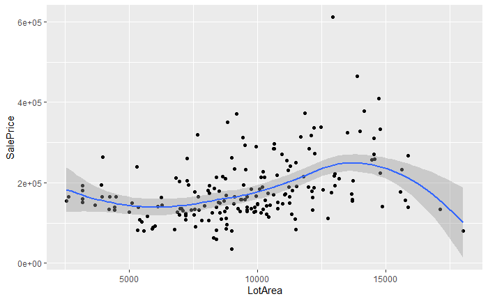

```r
ggplot(house_1, aes(x = LotArea, y = SalePrice)) +
  geom_point() +
  geom_smooth()
```

Now, you try to make 2 scatter plots with loess fit lines:

1. `SalePrice` against the area of second floor (`SFlrSF`).

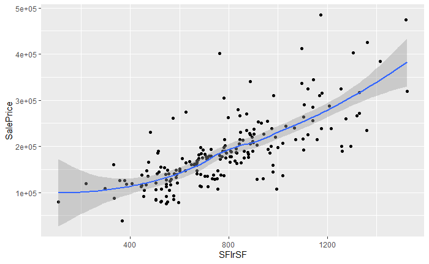

```r
ggplot(house_2, aes(x = SFlrSF, y = SalePrice)) +
  geom_point() +
  geom_smooth()
```

2. `SalePrice` against the total basement area (`TotalBsmtSF`).

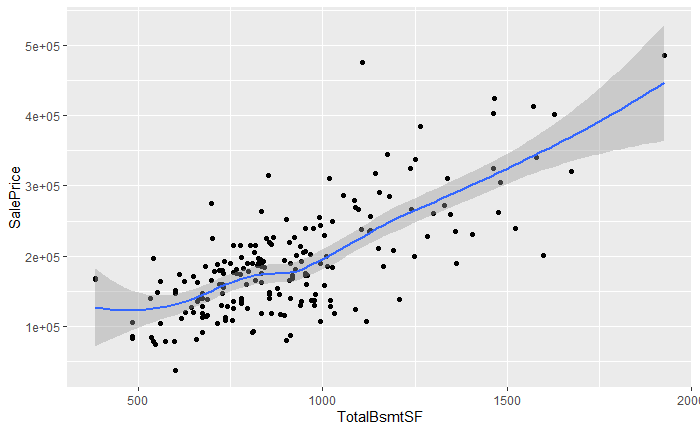

```r
ggplot(house_2, aes(x = TotalBsmtSF, y = SalePrice)) +
  geom_point() +
  geom_smooth()
```

In our previous plots, various area variables were mapped to the x aesthetic, so area is very interesting.

What if we want to plot `LotArea` and `GrLivArea` at the same time, and make comparison between them?

One method is to add another points geometry layer on the other using “+”:

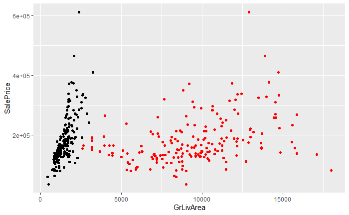

```r
ggplot(house_1, aes(x = GrLivArea, y = SalePrice)) +
  geom_point() +
  geom_point(aes(x = LotArea, y = SalePrice), col = "red")
```

Compared with the base R plot,

1. ggplot specifies a new x and y axis when we add a layer on top of the previous plot
2. Plotting space is adjusted for the new information
3. ggplot2 produces an object that we can manipulate

Although this works, this is not a correct way to do ggplot plots. One reason this is wrong is because there is no legend for the second group of data. So, please never do this.

## Data structure

To correctly plot the data set at hand, we need to think about the data sets first.

In previous plots, y variables are the same, both x variables are for Area. We plotted 3 variables, SalesPrice, LotArea and GrlivArea. In both base package and ggplot2, we layered 2 series of points on top of each other. In reality, we would rearrange the data to define variables in our data set according to what we are actually interested in.

Since both GrLivArea and LotArea are area, we want to gather the value of LotArea and GrlivArea into one cloumn. We could do this with package *tidyr*.

In package tidyr, function *gather* used to gather columns into rows. Function *spread* used to spread rows into columns.

Here we gathered the value of LotArea and GrLivArea into one column ‘Area’, and add another column ‘Type’ indicating the type of Area.

```r
houseTidy <- tidyr::gather(data = houseWide, key = "Type", value = 'Area', c(LotArea, GrLivArea))
```

Let’s have a look at the structure of out new data.

Now, both LotArea and GrlivArea are categories within Type variable.

```r
print(houseTidy)
```

[output not shown]

Now you try to gather the value of columns FFlrSF, SFlrSF, TotalBsmtSF into one column ‘Area’, and add a new column ‘Floor’ indicating the floor of the house, which is a categorical variable, the values of “Floor” are “FFlrSF”“,”SFlrSF“,”TotalBsmtSF".

```r
houseTidy2 <- gather(data = houseWide2, key = "Floor", value = "Area", c(FFlrSF, SFlrSF, TotalBsmtSF))
```

After you finished the transformation, have a look at the structure of your new data set use *print()*

```r
print(houseTidy2)
```

[output not shown]

Here we make scatter plot of SalePrice against GrlivArea and LotArea at once with our new data set.

```r
ggplot(houseTidy, aes(x = Area, y = SalePrice, color = Type)) +
  geom_point()
```

[output not shown]

In previous plots, we use different color to distinguish parts, so color is a scale, like the X axis and Y axis are scales.

Above is the typical way in which we use ggplot, the data is arranged to make the function calls as straightforward as possible.

We have 3 variables and we map them in 3 scales. Now we have the appearance of legend.

```r
ggplot(houseTidy2, aes(x = Area, y = SalePrice, color = Floor)) +
  geom_point()
```

[output not shown]

The proper way to make plots is not only easier, but a more accurate representation of the data.

```r
ggplot(houseTidy, aes(x = Area, y = SalePrice, col = Type)) +
  geom_point() +
  facet_grid(. ~ Style)
```

[output not shown]

Here you try to make a scatter plot of SalePrice against Area, comparing the impacts of variables Ages and Floor at the same time.

```r
ggplot(houseTidy2, aes(x = Area, y = SalePrice, col = Floor)) +
  geom_point() +
  facet_grid(. ~ Ages)
```

[output not shown]